# Team

Carlos A. Gonzalez

11/11/2019

#1-4

5. use nrow to check how many rows there are also use head() to tell you how many rows there are.
6. The best way to fix the skewness would be to cut off some of the data. The problem with that we will not see every single variable in the data set.

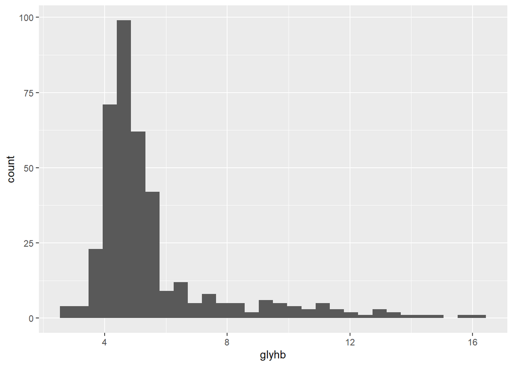

```r
ggplot(diabetes_cleaned, aes(glyhb)) + geom_histogram()
```

```r
#7.

glyhb_star= filter(diabetes_cleaned,glyhb <= 7)
glyhb_star
```

```
##     chol stab.glu hdl ratio glyhb   location age gender height weight
## 1    203       82  56   3.6  4.31 Buckingham  46 female     62    121
## 2    165       97  24   6.9  4.44 Buckingham  29 female     64    218
## 3    228       92  37   6.2  4.64 Buckingham  58 female     61    256
## 4     78       93  12   6.5  4.63 Buckingham  67   male     67    119
## 5    248       94  69   3.6  4.81 Buckingham  34   male     71    190
## 6    195       92  41   4.8  4.84 Buckingham  30   male     69    191
## 7    227       75  44   5.2  3.94 Buckingham  37   male     59    170
## 8    177       87  49   3.6  4.84 Buckingham  45   male     69    166
## 9    263       89  40   6.6  5.78 Buckingham  55 female     63    202
## 10   242       82  54   4.5  4.77     Louisa  60 female     65    156
## 11   215      128  34   6.3  4.97     Louisa  38 female     58    195
## 12   238       75  36   6.6  4.47     Louisa  27 female     60    170
## 13   183       79  46   4.0  4.59     Louisa  40 female     59    165
## 14   191       76  30   6.4  4.67     Louisa  36   male     69    183
```

[output cut: 647 more lines]

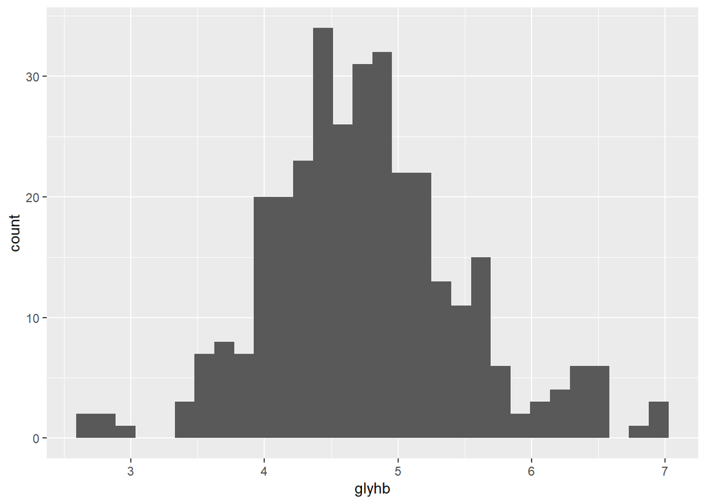

```r
ggplot(glyhb_star, aes(glyhb)) + geom_histogram()
```

8.

```r
summary(glyhb_star)
```

```
##       chol          stab.glu           hdl             ratio
##  Min.   : 78.0   Min.   : 48.00   Min.   : 12.00   Min.   : 1.500
##  1st Qu.:175.0   1st Qu.: 79.00   1st Qu.: 40.00   1st Qu.: 3.200
##  Median :199.0   Median : 86.50   Median : 47.00   Median : 4.100
##  Mean   :203.4   Mean   : 91.55   Mean   : 51.18   Mean   : 4.324
##  3rd Qu.:227.0   3rd Qu.: 97.00   3rd Qu.: 60.00   3rd Qu.: 5.300
##  Max.   :347.0   Max.   :371.00   Max.   :120.00   Max.   :10.600
##  NA's   :1                        NA's   :1        NA's   :1
##      glyhb             location        age           gender
##  Min.   :2.680   Buckingham:159   Min.   :19.00   female:194
##  1st Qu.:4.310   Louisa    :171   1st Qu.:32.00   male  :136
##  Median :4.685                    Median :42.00
##  Mean   :4.762                    Mean   :44.66
##  3rd Qu.:5.170                    3rd Qu.:55.75
##  Max.   :6.970                    Max.   :92.00
##
##      height          weight         frame         bp.1s
##  Min.   :52.00   Min.   : 99.0   large : 76   Min.   : 90.0
##  1st Qu.:63.00   1st Qu.:146.0   medium:152   1st Qu.:120.0
##  Median :66.00   Median :170.0   small : 93   Median :132.0
##  Mean   :65.95   Mean   :174.6   NA's  :  9   Mean   :135.2
##  3rd Qu.:69.00   3rd Qu.:195.8                3rd Qu.:142.0
##  Max.   :76.00   Max.   :325.0                Max.   :250.0
##  NA's   :4                                    NA's   :5
##      bp.1d         waist            hip           time.ppn
##  Min.   : 48   Min.   :26.00   Min.   :30.00   Min.   :   5.0
##  1st Qu.: 75   1st Qu.:33.00   1st Qu.:39.00   1st Qu.:  90.0
##  Median : 82   Median :37.00   Median :42.00   Median : 240.0
##  Mean   : 83   Mean   :37.35   Mean   :42.69   Mean   : 330.2
##  3rd Qu.: 90   3rd Qu.:41.00   3rd Qu.:46.00   3rd Qu.: 480.0
##  Max.   :124   Max.   :53.00   Max.   :64.00   Max.   :1560.0
##  NA's   :5     NA's   :2       NA's   :2       NA's   :3
```

```r
 diabetes_cleaned %>% group_by(frame,location) %>% summarise (mean.glyhb= mean(glyhb))
```

```
## # A tibble: 8 x 3
## # Groups:   frame [4]
##   frame  location   mean.glyhb
##   <fct>  <fct>           <dbl>
## 1 large  Buckingham      NA
## 2 large  Louisa           5.78
## 3 medium Buckingham      NA
## 4 medium Louisa          NA
## 5 small  Buckingham      NA
## 6 small  Louisa           5.34
## 7 <NA>   Buckingham      NA
## 8 <NA>   Louisa           4.68
```

11.Our main variable of interest is glyhb_star. We want to understand its relationship with ratio, bp.1s, age, gender, hip and weight. Further explore how these variables interact and visualize your findings.

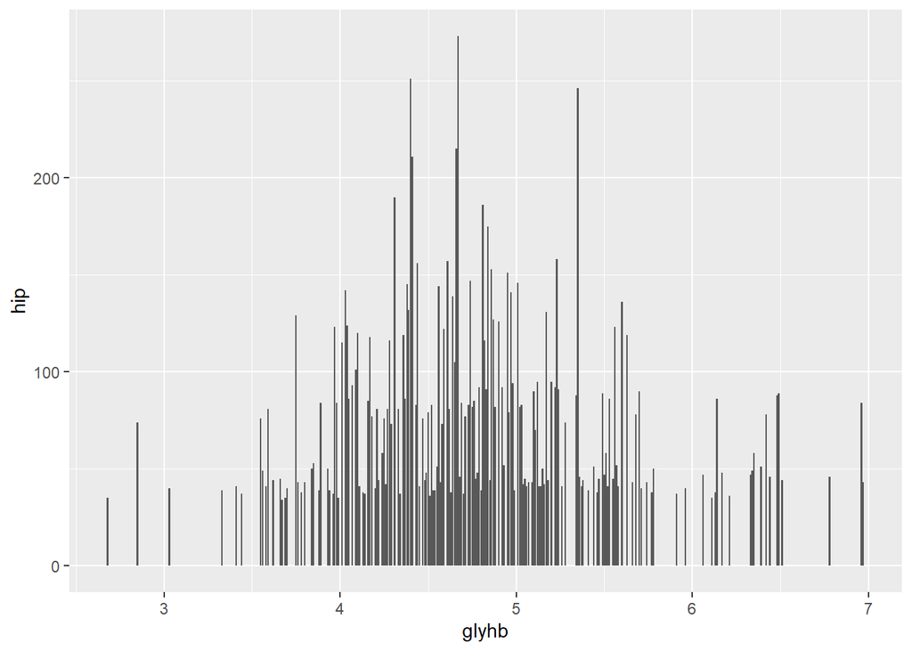

```r
ggplot(glyhb_star, aes(glyhb,hip)) + geom_col()
```

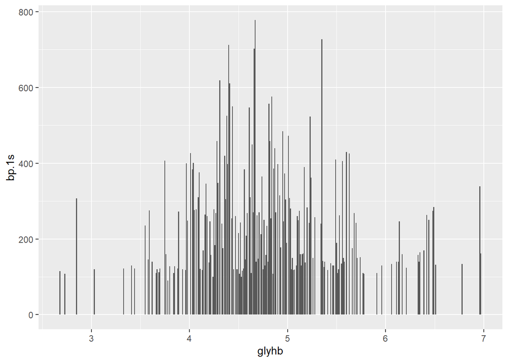

```r
ggplot(glyhb_star, aes(glyhb,bp.1s)) + geom_col()
```

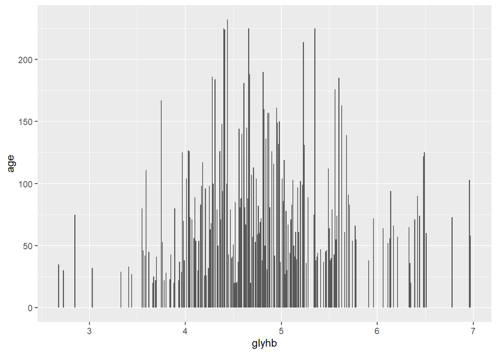

```r
ggplot(glyhb_star, aes(glyhb,age)) + geom_col()
```

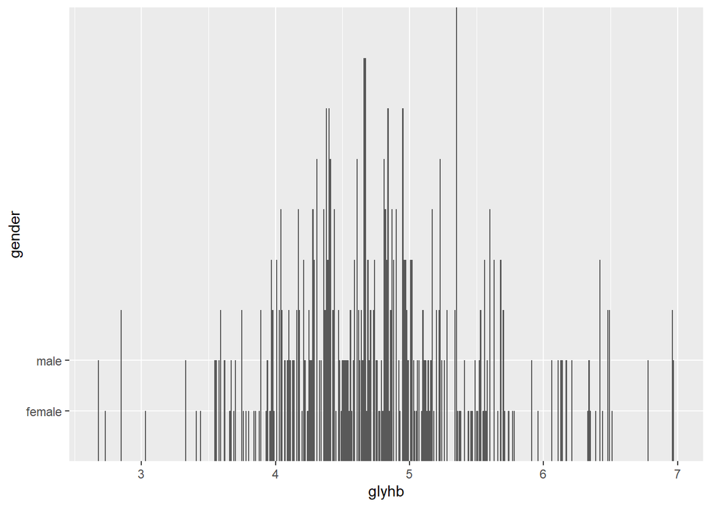

```r
ggplot(glyhb_star, aes(glyhb,gender)) + geom_col()
```

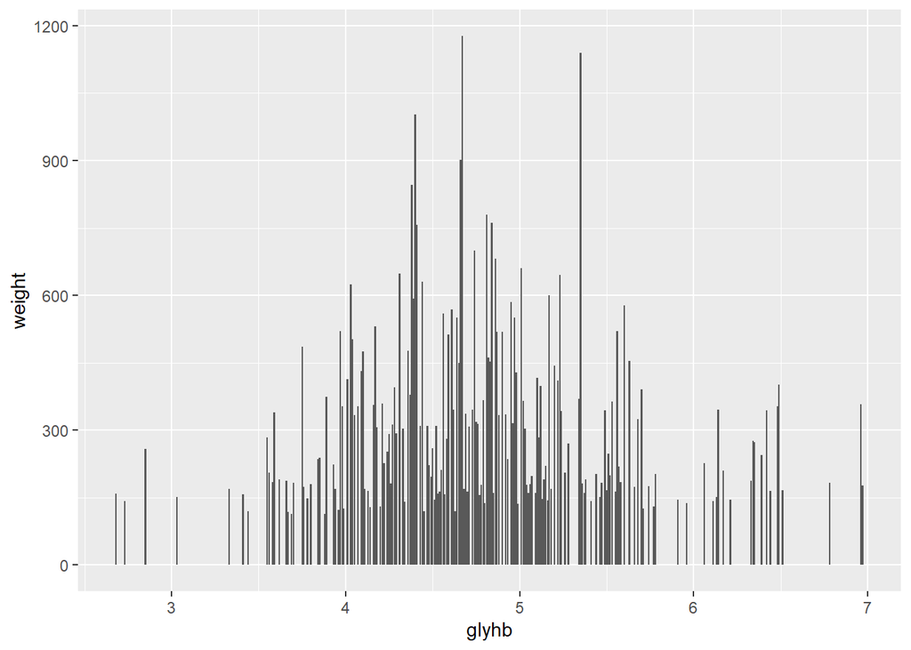

```r
ggplot(glyhb_star, aes(glyhb,weight)) + geom_col()
```

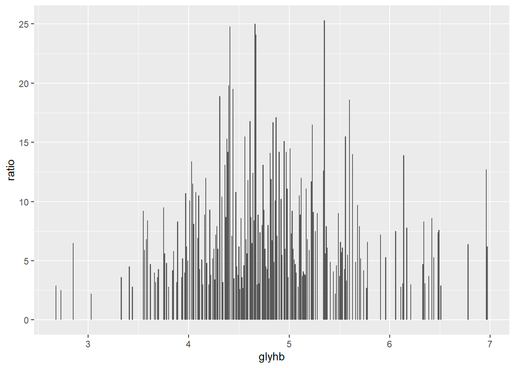

```r
ggplot(glyhb_star, aes(glyhb,ratio)) + geom_col()
```

12.

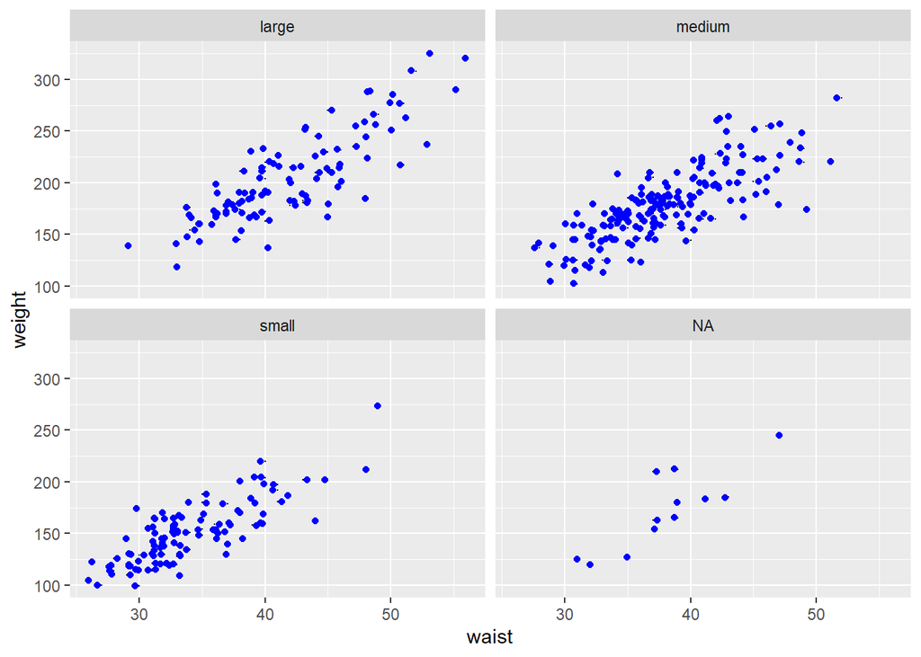

```r
ggplot(diabetes_cleaned,aes(y=weight,x=waist)) + geom_point(size = .001) + facet_wrap(~frame) +geom_jitter(colour = 'blue')
```

13. gather and spread may seem slightly unnatural to use at first, but they are very powerful functions that can transform data into the right format. Explain in your own words what the gather and spread functions do.

Gather brings columns together that have similar values. Spread moves rows into columns that have alike values.

14. Gather and spread are not complements because one brings columns together and then spread brings rows into columns

```r
fit = lm(glyhb ~stab.glu + age + waist + ratio+ factor(frame),data=diabetes_cleaned)
 summary(fit)
```

```
##
## Call:
## lm(formula = glyhb ~ stab.glu + age + waist + ratio + factor(frame),
##     data = diabetes_cleaned)
##
## Residuals:
##     Min      1Q  Median      3Q     Max
## -8.4197 -0.7473 -0.1594  0.4731  9.5789
##
## Coefficients:
##                     Estimate Std. Error t value Pr(>|t|)
## (Intercept)         0.467469   0.682984   0.684 0.494120
## stab.glu            0.028388   0.001516  18.722  < 2e-16 ***
## age                 0.017656   0.004997   3.533 0.000463 ***
## waist               0.012541   0.015483   0.810 0.418491
## ratio               0.141210   0.047436   2.977 0.003104 **
## factor(frame)medium 0.263056   0.196389   1.339 0.181244
## factor(frame)small  0.127934   0.242677   0.527 0.598387
## ---
## Signif. codes:  0 '***' 0.001 '**' 0.01 '*' 0.05 '.' 0.1 ' ' 1
##
## Residual standard error: 1.461 on 369 degrees of freedom
##   (27 observations deleted due to missingness)
## Multiple R-squared:  0.5899, Adjusted R-squared:  0.5832
## F-statistic: 88.45 on 6 and 369 DF,  p-value: < 2.2e-16
```

Interpret the estimated regression coefficient for each predictor in fit, regardless of whether or not the predictor is significant.

The Regression Coefficient is positive so It will be going at a Positve rate.

```r
fit$fitted.values
```

[output not shown]

[output cut: 53 more lines]

[output not shown]

```r
#It fit the vlaue of the true mean of Y.
```

18. Explain the difference between inference and prediction.

Inference is making an educated guess through facts and observations. Prediction is making a guess on what might happen

19.What are advantages/disadvantages to constructing a linear regression model as opposed to a k-NN regression model? Advantages would be that it easy to work with and it is easy to learn. A Disadvantage would be that it only work with linear problems where as K-NN works with non linear problems.

20. Reflection On your very first HW, I asked you what you think data science is. Have your views changed?

The views of Data Science has not changed since we both have experience in the field. Discuss with your partner what you have found to be (1) most surprising about data science, (2) most challenging, and (3) most enjoyable. Write a brief paragraph addressing these points.

1. The most surprising thing about data science is that there is no one path. Data keeps evolving so answers/solution may always change.
2. The most challenging part of data science is cleaning the data and having it organized.
3. The most enjoyable part of data science is creating graphs and using our own style to present our findings.